# **Air Quality Prediction using Statistical and Machine Learning Models**

### (2) AQI Forecast Using XGBoost

```python
#import library
import os
import pandas as pd
import missingno as msno
import matplotlib.pyplot as plt
import seaborn as sns
import numpy as np

import xgboost as xgb
from sklearn.metrics import mean_squared_error
color_pal = sns.color_palette()
plt.style.use('fivethirtyeight')

import plotly.io as pio
import plotly.express as px
from statsmodels.graphics.tsaplots import plot_acf
from statsmodels.tsa.seasonal import STL
from statsmodels.tsa.statespace.structural import UnobservedComponents
from statsmodels.tsa.seasonal import seasonal_decompose
```

```python
#read the data
data_annan = pd.read_pickle("Annan_45_modified.xz")
print(data_annan.columns.tolist())
len(data_annan)
```

```
['siteid', 'sitename', 'siteengname', 'county', 'countyen', 'Year', 'aqi', 'pollutant', 'status', 'so2', 'co', 'o3', 'o3_8hr', 'pm10', 'pm2.5', 'no2', 'nox', 'no', 'windspeed', 'winddirec', 'co_8hr', 'pm2.5_avg', 'pm10_avg', 'so2_avg']
```

```
72696
```

```python
#selected the colom and remove null data
selected_cols = ['aqi', 'so2', 'co', 'o3', 'pm10', 'pm2.5', 'no2', 'nox', 'no']
data_annan = data_annan.dropna(subset=selected_cols)
```

```python
def create_time_features(df):
    """Create time-based features"""
    df = df.copy()
    df['hour'] = df.index.hour
    df['dayofweek'] = df.index.dayofweek
    df['quarter'] = df.index.quarter
    df['month'] = df.index.month
    df['year'] = df.index.year
    df['dayofyear'] = df.index.dayofyear
    df['dayofmonth'] = df.index.day
    df['weekofyear'] = df.index.isocalendar().week
    return df
```

```python
def create_seasonal_features(train_df, target_cols):
    """Create seasonal decomposition features using only training data"""
    seasonal_features = {}

    for col in target_cols:
        # Decompose using only training data
        decomp = seasonal_decompose(train_df[col], period=24, model='additive', extrapolate_trend='freq')

        # Store seasonal patterns
        seasonal_features[f'{col}_seasonal_pattern'] = decomp.seasonal[:24].values  # 24-hour pattern
        seasonal_features[f'{col}_trend_slope'] = np.nanmean(np.diff(decomp.trend))  # average trend

    return seasonal_features
```

```python
def apply_seasonal_features(df, seasonal_patterns):
    """Apply seasonal patterns to any dataframe"""
    df = df.copy()

    for col in selected_cols:
        # Apply 24-hour seasonal pattern
        seasonal_key = f'{col}_seasonal_pattern'
        if seasonal_key in seasonal_patterns:
            df[f'{col}_seasonal'] = [seasonal_patterns[seasonal_key][hour] for hour in df.index.hour]

        # Apply trend (simple linear trend based on training data)
        trend_key = f'{col}_trend_slope'
        if trend_key in seasonal_patterns:
            # Calculate days from start of training
            start_date = df.index.min()
            days_from_start = (df.index - start_date).days
            df[f'{col}_trend'] = seasonal_patterns[trend_key] * days_from_start

    return df
```

```python
def create_lag_features(df, target_col, lags=[1, 24, 168]):  # 1h, 1day, 1week
    """Create lag features safely"""
    df = df.copy()

    for lag in lags:
        df[f'{target_col}_lag{lag}'] = df[target_col].shift(lag)

    return df
```

```python
# Create seasonal patterns from training data only
seasonal_patterns = create_seasonal_features(data_annan, selected_cols)
```

```python
# Create seasonal patterns from training data only
seasonal_patterns = create_seasonal_features(data_annan, selected_cols)
# Prepare training data
train_df = create_time_features(data_annan)
train_df = apply_seasonal_features(train_df, seasonal_patterns)
train_df = create_lag_features(train_df, 'aqi', lags=[1, 24, 168])
```

```python
# Remove rows with NaN (due to lag features)
col_remove = ['siteid','sitename', 'siteengname','so2_avg','pm10_avg', 'pm2.5_avg', 'co_8hr', 'winddirec', 'windspeed', 'o3_8hr', 'pollutant','county','countyen','Year','status']
train_df = train_df.drop(columns=col_remove)
```

```python
train_df
```

| datacreationdate | aqi | so2 | co | o3 | pm10 | pm2.5 | no2 | nox | no | hour | ... | pm2.5_trend | no2_seasonal | no2_trend | nox_seasonal | nox_trend | no_seasonal | no_trend | aqi_lag1 | aqi_lag24 | aqi_lag168 |
| --- | --- | --- | --- | --- | --- | --- | --- | --- | --- | --- | --- | --- | --- | --- | --- | --- | --- | --- | --- | --- | --- |
| 2016-11-25 13:00:00 | 52.0 | 2.9 | 0.26 | 58.0 | 53.0 | 19.0 | 9.4 | 12.0 | 2.5 | 13 | ... | -0.00000 | -0.151072 | -0.000000 | -0.132028 | -0.000000 | 0.013798 | -0.00000 | NaN | NaN | NaN |
| 2016-11-25 14:00:00 | 52.0 | 2.4 | 0.24 | 61.0 | 54.0 | 16.0 | 7.8 | 9.7 | 1.8 | 14 | ... | -0.00000 | -0.140368 | -0.000000 | -0.108315 | -0.000000 | 0.026852 | -0.00000 | 52.0 | NaN | NaN |
| 2016-11-25 15:00:00 | 49.0 | 2.1 | 0.22 | 58.0 | 55.0 | 25.0 | 7.7 | 9.6 | 1.9 | 15 | ... | -0.00000 | -0.203278 | -0.000000 | -0.132022 | -0.000000 | 0.063942 | -0.00000 | 52.0 | NaN | NaN |
| 2016-11-25 16:00:00 | 45.0 | 2.4 | 0.24 | 62.0 | 59.0 | 17.0 | 8.5 | 10.0 | 2.0 | 16 | ... | -0.00000 | -0.163773 | -0.000000 | -0.129577 | -0.000000 | 0.036225 | -0.00000 | 49.0 | NaN | NaN |
| 2016-11-25 17:00:00 | 45.0 | 2.5 | 0.27 | 63.0 | 57.0 | 19.0 | 9.5 | 11.0 | 1.6 | 17 | ... | -0.00000 | -0.011235 | -0.000000 | -0.016728 | -0.000000 | -0.005885 | -0.00000 | 45.0 | NaN | NaN |
| ... | ... | ... | ... | ... | ... | ... | ... | ... | ... | ... | ... | ... | ... | ... | ... | ... | ... | ... | ... | ... | ... |
| 2025-03-31 19:00:00 | 58.0 | 0.9 | 0.32 | 20.0 | 21.0 | 14.0 | 17.0 | 19.2 | 1.6 | 19 | ... | -0.91691 | 0.083378 | -0.611929 | 0.124429 | -0.780231 | 0.045166 | -0.18035 | 57.0 | 50.0 | 68.0 |
| 2025-03-31 20:00:00 | 55.0 | 1.1 | 0.29 | 20.0 | 20.0 | 13.0 | 16.0 | 18.1 | 1.4 | 20 | ... | -0.91691 | 0.100242 | -0.611929 | 0.131003 | -0.780231 | 0.032346 | -0.18035 | 58.0 | 47.0 | 84.0 |
| 2025-03-31 21:00:00 | 54.0 | 1.0 | 0.26 | 26.0 | 23.0 | 13.0 | 11.0 | 12.9 | 1.2 | 21 | ... | -0.91691 | 0.061541 | -0.611929 | 0.085365 | -0.780231 | 0.023157 | -0.18035 | 55.0 | 38.0 | 71.0 |
| 2025-03-31 22:00:00 | 52.0 | 1.1 | 0.24 | 29.0 | 15.0 | 10.0 | 9.0 | 11.1 | 1.1 | 22 | ... | -0.91691 | 0.115277 | -0.611929 | 0.051175 | -0.780231 | -0.063570 | -0.18035 | 54.0 | 37.0 | 58.0 |
| 2025-03-31 23:00:00 | 48.0 | 1.1 | 0.23 | 30.0 | 10.0 | 9.0 | 8.0 | 9.6 | 0.9 | 23 | ... | -0.91691 | 0.093707 | -0.611929 | -0.024920 | -0.780231 | -0.114178 | -0.18035 | 52.0 | 37.0 | 56.0 |

68199 rows × 38 columns

```python
# Define features
time_features = ['hour', 'dayofweek', 'month', 'dayofyear']
seasonal_features = [f'{col}_seasonal' for col in selected_cols] + [f'{col}_trend' for col in selected_cols]
lag_features = ['aqi_lag1', 'aqi_lag24', 'aqi_lag168']
pollution_features = [col for col in selected_cols if col != 'aqi']  # Use other pollutants as features

FEATURES = time_features + seasonal_features + lag_features + pollution_features
TARGET = 'aqi'

print(f"Total features: {len(FEATURES)}")
print(f"Features: {FEATURES}")
```

```
Total features: 33
Features: ['hour', 'dayofweek', 'month', 'dayofyear', 'aqi_seasonal', 'so2_seasonal', 'co_seasonal', 'o3_seasonal', 'pm10_seasonal', 'pm2.5_seasonal', 'no2_seasonal', 'nox_seasonal', 'no_seasonal', 'aqi_trend', 'so2_trend', 'co_trend', 'o3_trend', 'pm10_trend', 'pm2.5_trend', 'no2_trend', 'nox_trend…
```

```python
from sklearn.model_selection import TimeSeriesSplit
tss = TimeSeriesSplit(n_splits=5, test_size=24*365*1, gap=24)
df_copy =train_df.copy()
df_copy=df_copy.sort_index()
```

```python
df_copy
```

| datacreationdate | aqi | so2 | co | o3 | pm10 | pm2.5 | no2 | nox | no | hour | ... | pm2.5_trend | no2_seasonal | no2_trend | nox_seasonal | nox_trend | no_seasonal | no_trend | aqi_lag1 | aqi_lag24 | aqi_lag168 |
| --- | --- | --- | --- | --- | --- | --- | --- | --- | --- | --- | --- | --- | --- | --- | --- | --- | --- | --- | --- | --- | --- |
| 2016-11-25 13:00:00 | 52.0 | 2.9 | 0.26 | 58.0 | 53.0 | 19.0 | 9.4 | 12.0 | 2.5 | 13 | ... | -0.00000 | -0.151072 | -0.000000 | -0.132028 | -0.000000 | 0.013798 | -0.00000 | NaN | NaN | NaN |
| 2016-11-25 14:00:00 | 52.0 | 2.4 | 0.24 | 61.0 | 54.0 | 16.0 | 7.8 | 9.7 | 1.8 | 14 | ... | -0.00000 | -0.140368 | -0.000000 | -0.108315 | -0.000000 | 0.026852 | -0.00000 | 52.0 | NaN | NaN |
| 2016-11-25 15:00:00 | 49.0 | 2.1 | 0.22 | 58.0 | 55.0 | 25.0 | 7.7 | 9.6 | 1.9 | 15 | ... | -0.00000 | -0.203278 | -0.000000 | -0.132022 | -0.000000 | 0.063942 | -0.00000 | 52.0 | NaN | NaN |
| 2016-11-25 16:00:00 | 45.0 | 2.4 | 0.24 | 62.0 | 59.0 | 17.0 | 8.5 | 10.0 | 2.0 | 16 | ... | -0.00000 | -0.163773 | -0.000000 | -0.129577 | -0.000000 | 0.036225 | -0.00000 | 49.0 | NaN | NaN |
| 2016-11-25 17:00:00 | 45.0 | 2.5 | 0.27 | 63.0 | 57.0 | 19.0 | 9.5 | 11.0 | 1.6 | 17 | ... | -0.00000 | -0.011235 | -0.000000 | -0.016728 | -0.000000 | -0.005885 | -0.00000 | 45.0 | NaN | NaN |
| ... | ... | ... | ... | ... | ... | ... | ... | ... | ... | ... | ... | ... | ... | ... | ... | ... | ... | ... | ... | ... | ... |
| 2025-03-31 19:00:00 | 58.0 | 0.9 | 0.32 | 20.0 | 21.0 | 14.0 | 17.0 | 19.2 | 1.6 | 19 | ... | -0.91691 | 0.083378 | -0.611929 | 0.124429 | -0.780231 | 0.045166 | -0.18035 | 57.0 | 50.0 | 68.0 |
| 2025-03-31 20:00:00 | 55.0 | 1.1 | 0.29 | 20.0 | 20.0 | 13.0 | 16.0 | 18.1 | 1.4 | 20 | ... | -0.91691 | 0.100242 | -0.611929 | 0.131003 | -0.780231 | 0.032346 | -0.18035 | 58.0 | 47.0 | 84.0 |
| 2025-03-31 21:00:00 | 54.0 | 1.0 | 0.26 | 26.0 | 23.0 | 13.0 | 11.0 | 12.9 | 1.2 | 21 | ... | -0.91691 | 0.061541 | -0.611929 | 0.085365 | -0.780231 | 0.023157 | -0.18035 | 55.0 | 38.0 | 71.0 |
| 2025-03-31 22:00:00 | 52.0 | 1.1 | 0.24 | 29.0 | 15.0 | 10.0 | 9.0 | 11.1 | 1.1 | 22 | ... | -0.91691 | 0.115277 | -0.611929 | 0.051175 | -0.780231 | -0.063570 | -0.18035 | 54.0 | 37.0 | 58.0 |
| 2025-03-31 23:00:00 | 48.0 | 1.1 | 0.23 | 30.0 | 10.0 | 9.0 | 8.0 | 9.6 | 0.9 | 23 | ... | -0.91691 | 0.093707 | -0.611929 | -0.024920 | -0.780231 | -0.114178 | -0.18035 | 52.0 | 37.0 | 56.0 |

68199 rows × 38 columns

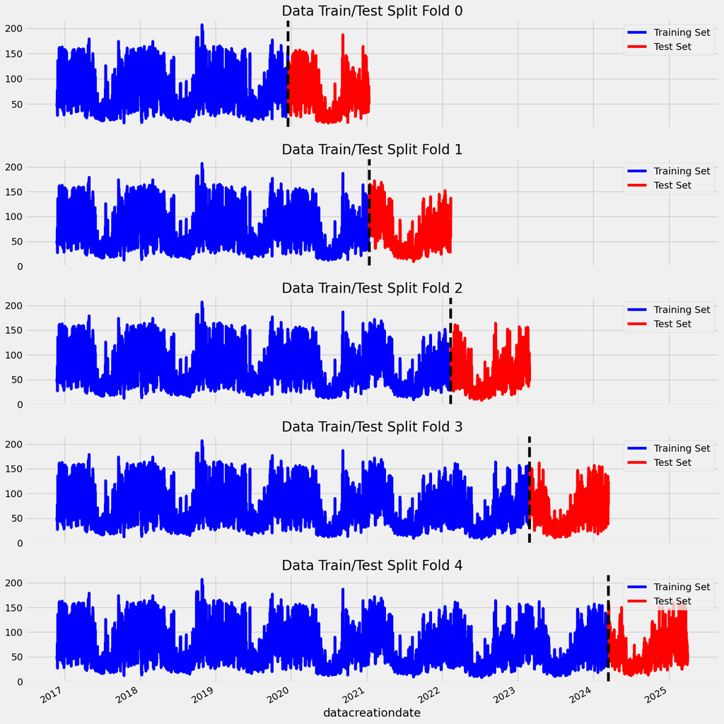

```python
# Visualize train/test splits
fig, axs = plt.subplots(5, 1, figsize=(15, 15), sharex=True)

fold = 0
for train_idx, val_idx in tss.split(df_copy):
    train_fold_data = df_copy.iloc[train_idx]
    val_fold_data = df_copy.iloc[val_idx]

    train_fold_data[TARGET].plot(ax=axs[fold], color='blue', legend=False,
                                title=f'Data Train/Test Split Fold {fold}')
    val_fold_data[TARGET].plot(ax=axs[fold], color='red', legend=True)

    axs[fold].legend(['Training Set', 'Test Set'])
    axs[fold].axvline(val_fold_data.index.min(), color='black', ls='--')

    fold += 1

plt.tight_layout()
plt.show()
```

```python
# Cross validation
from sklearn.model_selection import TimeSeriesSplit
tss = TimeSeriesSplit(n_splits=5, test_size=24*365*1, gap=24)
df_copy =train_df.copy()
df_copy=df_copy.sort_index()

fold = 0
preds = []
scores = []

for train_idx, val_idx in tss.split(df_copy):
    train_fold = df_copy.iloc[train_idx].copy()
    test_fold = df_copy.iloc[val_idx].copy()

    train_fold = create_time_features(train_fold)
    test_fold = create_time_features(test_fold)

    FEATURES = FEATURES
    TARGET = 'aqi'

    X_train = train_fold[FEATURES]
    y_train = train_fold[TARGET]

    X_test = test_fold[FEATURES]
    y_test = test_fold[TARGET]

    reg = xgb.XGBRegressor(base_score=0.5, booster='gbtree',
                           n_estimators=1500,
                           early_stopping_rounds=50,
                           objective='reg:squarederror',
                           max_depth=3,
                           learning_rate=0.01)
    reg.fit(X_train, y_train,
            eval_set=[(X_train, y_train), (X_test, y_test)],
            verbose=100)

    y_pred = reg.predict(X_test)
    preds.append(y_pred)
    score = np.sqrt(mean_squared_error(y_test, y_pred))
    scores.append(score)
```

```python
df_copy
```

| datacreationdate | aqi | so2 | co | o3 | pm10 | pm2.5 | no2 | nox | no | hour | ... | pm2.5_trend | no2_seasonal | no2_trend | nox_seasonal | nox_trend | no_seasonal | no_trend | aqi_lag1 | aqi_lag24 | aqi_lag168 |
| --- | --- | --- | --- | --- | --- | --- | --- | --- | --- | --- | --- | --- | --- | --- | --- | --- | --- | --- | --- | --- | --- |
| 2016-11-25 13:00:00 | 52.0 | 2.9 | 0.26 | 58.0 | 53.0 | 19.0 | 9.4 | 12.0 | 2.5 | 13 | ... | -0.00000 | -0.151072 | -0.000000 | -0.132028 | -0.000000 | 0.013798 | -0.00000 | NaN | NaN | NaN |
| 2016-11-25 14:00:00 | 52.0 | 2.4 | 0.24 | 61.0 | 54.0 | 16.0 | 7.8 | 9.7 | 1.8 | 14 | ... | -0.00000 | -0.140368 | -0.000000 | -0.108315 | -0.000000 | 0.026852 | -0.00000 | 52.0 | NaN | NaN |
| 2016-11-25 15:00:00 | 49.0 | 2.1 | 0.22 | 58.0 | 55.0 | 25.0 | 7.7 | 9.6 | 1.9 | 15 | ... | -0.00000 | -0.203278 | -0.000000 | -0.132022 | -0.000000 | 0.063942 | -0.00000 | 52.0 | NaN | NaN |
| 2016-11-25 16:00:00 | 45.0 | 2.4 | 0.24 | 62.0 | 59.0 | 17.0 | 8.5 | 10.0 | 2.0 | 16 | ... | -0.00000 | -0.163773 | -0.000000 | -0.129577 | -0.000000 | 0.036225 | -0.00000 | 49.0 | NaN | NaN |
| 2016-11-25 17:00:00 | 45.0 | 2.5 | 0.27 | 63.0 | 57.0 | 19.0 | 9.5 | 11.0 | 1.6 | 17 | ... | -0.00000 | -0.011235 | -0.000000 | -0.016728 | -0.000000 | -0.005885 | -0.00000 | 45.0 | NaN | NaN |
| ... | ... | ... | ... | ... | ... | ... | ... | ... | ... | ... | ... | ... | ... | ... | ... | ... | ... | ... | ... | ... | ... |
| 2025-03-31 19:00:00 | 58.0 | 0.9 | 0.32 | 20.0 | 21.0 | 14.0 | 17.0 | 19.2 | 1.6 | 19 | ... | -0.91691 | 0.083378 | -0.611929 | 0.124429 | -0.780231 | 0.045166 | -0.18035 | 57.0 | 50.0 | 68.0 |
| 2025-03-31 20:00:00 | 55.0 | 1.1 | 0.29 | 20.0 | 20.0 | 13.0 | 16.0 | 18.1 | 1.4 | 20 | ... | -0.91691 | 0.100242 | -0.611929 | 0.131003 | -0.780231 | 0.032346 | -0.18035 | 58.0 | 47.0 | 84.0 |
| 2025-03-31 21:00:00 | 54.0 | 1.0 | 0.26 | 26.0 | 23.0 | 13.0 | 11.0 | 12.9 | 1.2 | 21 | ... | -0.91691 | 0.061541 | -0.611929 | 0.085365 | -0.780231 | 0.023157 | -0.18035 | 55.0 | 38.0 | 71.0 |
| 2025-03-31 22:00:00 | 52.0 | 1.1 | 0.24 | 29.0 | 15.0 | 10.0 | 9.0 | 11.1 | 1.1 | 22 | ... | -0.91691 | 0.115277 | -0.611929 | 0.051175 | -0.780231 | -0.063570 | -0.18035 | 54.0 | 37.0 | 58.0 |
| 2025-03-31 23:00:00 | 48.0 | 1.1 | 0.23 | 30.0 | 10.0 | 9.0 | 8.0 | 9.6 | 0.9 | 23 | ... | -0.91691 | 0.093707 | -0.611929 | -0.024920 | -0.780231 | -0.114178 | -0.18035 | 52.0 | 37.0 | 56.0 |

68199 rows × 38 columns

```python
print(f'Score across folds {np.mean(scores):0.4f}')
print(f'Fold scores:{scores}')
```

```
Score across folds 2.9080
Fold scores:[3.11321359828028, 2.7846744456763366, 2.6073350130535924, 3.2395557877593864, 2.7954017126509583]
```

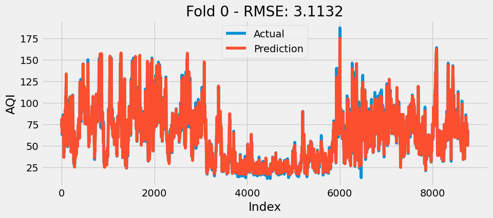

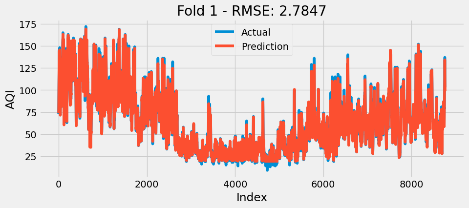

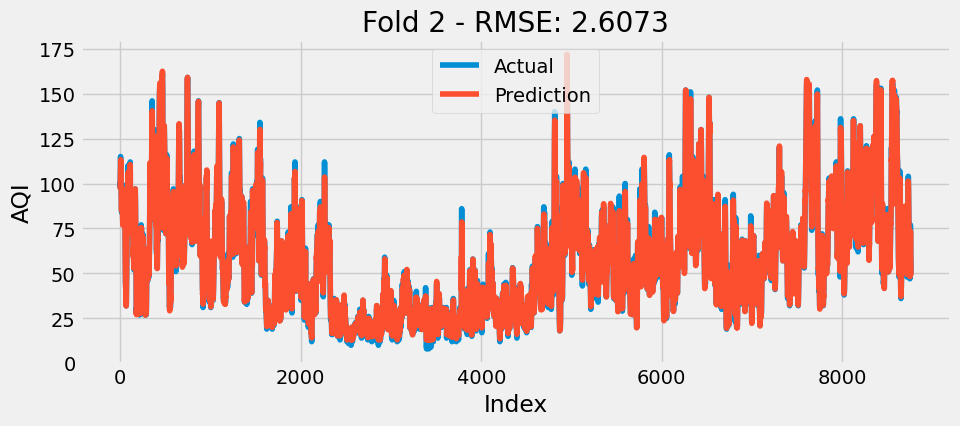

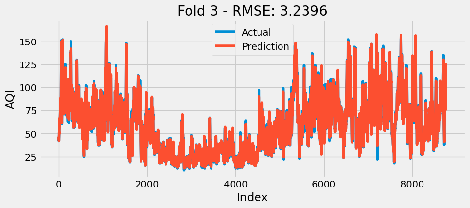

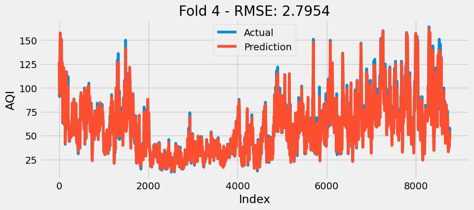

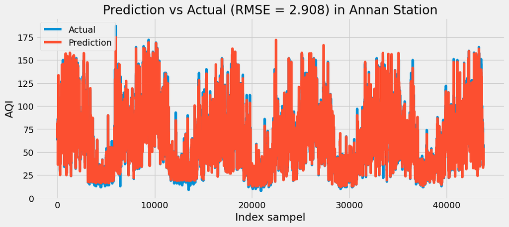

```python
# Combine all predicted and actual results for a combined visualization.
all_y_true = []
all_y_pred = []

for i, (train_idx, val_idx) in enumerate(tss.split(df_copy)):
    # Take the actual y_test for fold i
    test_fold = df_copy.iloc[val_idx].copy()
    test_fold = create_time_features(test_fold)
    y_test = test_fold['aqi'].values

    y_pred = preds[i]

    all_y_true.extend(y_test)
    all_y_pred.extend(y_pred)

    # visualization per fold
    plt.figure(figsize=(10,4))
    plt.plot(y_test, label='Actual')
    plt.plot(y_pred, label='Prediction')
    plt.title(f'Fold {i} - RMSE: {scores[i]:.4f}')
    plt.xlabel('Index')
    plt.ylabel('AQI')
    plt.legend()
    plt.show()

# Combined visualization of all folds
plt.figure(figsize=(12,5))
plt.plot(all_y_true, label='Actual')
plt.plot(all_y_pred, label='Prediction')
plt.title('Prediction vs Actual (RMSE = 2.908) in Annan Station')
plt.xlabel('Index sampel')
plt.ylabel('AQI')
plt.legend()
plt.show()
```

```python
#Retrain on all data
df_all = create_time_features(df_copy)

FEATURES = FEATURES
TARGET = 'aqi'

X_all = df_all[FEATURES]
y_all = df_all[TARGET]

# Latih ulang model di seluruh data
reg = xgb.XGBRegressor(base_score=0.5,
                       booster='gbtree',
                       n_estimators=1500,
                       objective='reg:squarederror',
                       max_depth=3,
                       learning_rate=0.01)

reg.fit(X_all, y_all,
        eval_set=[(X_all, y_all)],
        verbose=100)

# Feature importance
feature_importance = pd.DataFrame({
    'feature': FEATURES,
    'importance': reg.feature_importances_
}).sort_values('importance', ascending=False)

print("\nTop 10 Most Important Features:")
print(feature_importance.head(10))
```

```
Top 10 Most Important Features:
         feature  importance
22      aqi_lag1    0.907489
29         pm2.5    0.057997
28          pm10    0.010659
27            o3    0.005158
0           hour    0.004176
4   aqi_seasonal    0.003919
7    o3_seasonal    0.002707
3      dayofyear    0.001304
26            co    0.001107
13     aqi_trend    0.001010
```

Forecasting 1 Year

```python
import pandas as pd
import numpy as np
import matplotlib.pyplot as plt
import seaborn as sns
from datetime import datetime, timedelta
import warnings
warnings.filterwarnings('ignore')
```

```python
def create_future_dates(last_date, periods=24*365):
    """
    Create a date for forecasting
    periods: number of hours for prediction (24*365 = 1 year)
    """
    future_dates = pd.date_range(
        start=last_date + timedelta(hours=1),
        periods=periods,
        freq='H'
    )
    return future_dates
```

```python
def create_future_dataframe(future_dates, seasonal_patterns, last_known_values):
    """
    Create a dataframe for forecasting with all the necessary features
    """
    future_df = pd.DataFrame(index=future_dates)

    # 1. Time features (according to those used in the model)
    future_df['hour'] = future_df.index.hour
    future_df['dayofweek'] = future_df.index.dayofweek
    future_df['quarter'] = future_df.index.quarter
    future_df['month'] = future_df.index.month
    future_df['year'] = future_df.index.year
    future_df['dayofyear'] = future_df.index.dayofyear
    future_df['dayofmonth'] = future_df.index.day
    future_df['weekofyear'] = future_df.index.isocalendar().week

    # 2. Apply seasonal features for all pollutants
    all_pollutants = ['aqi', 'so2', 'co', 'o3', 'pm10', 'pm2.5', 'no2', 'nox', 'no']
    for pollutant in all_pollutants:
        # Apply 24-hour seasonal pattern
        seasonal_key = f'{pollutant}_seasonal_pattern'
        if seasonal_key in seasonal_patterns:
            future_df[f'{pollutant}_seasonal'] = [seasonal_patterns[seasonal_key][hour % 24]
                                                 for hour in future_df.index.hour]

        # Apply trend
        trend_key = f'{pollutant}_trend_slope'
        if trend_key in seasonal_patterns:
            start_date = future_df.index.min()
            days_from_start = (future_df.index - start_date).days
            future_df[f'{pollutant}_trend'] = seasonal_patterns[trend_key] * days_from_start

    # 3. initialize pollutant values with the last known values
    pollutants = ['so2', 'co', 'o3', 'pm10', 'pm2.5', 'no2', 'nox', 'no']
    for pollutant in pollutants:
        future_df[pollutant] = last_known_values[pollutant]

    # 4. Initialize aqi with the last value (will be updated in the prediction loop)
    future_df['aqi'] = last_known_values['aqi']

    # 5. Initialize lag features with last values
    future_df['aqi_lag1'] = last_known_values['aqi']
    future_df['aqi_lag24'] = last_known_values['aqi']
    future_df['aqi_lag168'] = last_known_values['aqi']

    return future_df
```

```python
def multi_step_forecast(model, future_df, features, n_steps, historical_data, seed=42):
    """
    Performing multi-step forecasting with update lag features
    """
    np.random.seed(seed)
    predictions = []
    future_df_copy = future_df.copy()

    # Cache column indices for efficiency
    try:
        aqi_idx = future_df_copy.columns.get_loc('aqi')  # ← Ini yang hilang!
        aqi_lag1_idx = future_df_copy.columns.get_loc('aqi_lag1')
        aqi_lag24_idx = future_df_copy.columns.get_loc('aqi_lag24')
        aqi_lag168_idx = future_df_copy.columns.get_loc('aqi_lag168')
    except KeyError as e:
        raise ValueError(f"Required column not found: {e}")

    historical_aqi = historical_data['aqi'].values

    for i in range(n_steps):
        # Update aqi value based on previous predictions
        if i > 0:
            future_df_copy.iloc[i, aqi_idx] = predictions[i-1]  # ← Sekarang menggunakan aqi_idx

        # Update lag features
        if i >= 1:
            future_df_copy.iloc[i, aqi_lag1_idx] = predictions[i-1]

        if i >= 24:
            future_df_copy.iloc[i, aqi_lag24_idx] = predictions[i-24]

        # for lag168
        lag168_index = len(historical_aqi) + i - 168
        if lag168_index >= 0:
            if lag168_index < len(historical_aqi):
                lag168_value = historical_aqi[lag168_index]
            else:
                pred_index = lag168_index - len(historical_aqi)
                lag168_value = predictions[pred_index]
            future_df_copy.iloc[i, aqi_lag168_idx] = lag168_value

        # Update pollutant values
        if i > 0:
            for pollutant in ['so2', 'co', 'o3', 'pm10', 'pm2.5', 'no2', 'nox', 'no']:
                seasonal_val = future_df_copy.iloc[i][f'{pollutant}_seasonal']
                trend_val = future_df_copy.iloc[i][f'{pollutant}_trend']
                base_val = future_df_copy.iloc[i-1][pollutant]

                seasonal_factor = 1 + (seasonal_val / (abs(seasonal_val) + 1)) * 0.1
                noise = np.random.normal(0, base_val * 0.02)

                new_val = max(0, base_val * seasonal_factor + trend_val * 0.001 + noise)
                pollutant_idx = future_df_copy.columns.get_loc(pollutant)
                future_df_copy.iloc[i, pollutant_idx] = new_val

        # Prediction
        X_current = future_df_copy.iloc[i:i+1][features]  # use 'features' parameter
        pred = model.predict(X_current)[0]
        predictions.append(pred)

        if (i + 1) % 1000 == 0:
            print(f"Progress: {i+1}/{n_steps} steps completed ({(i+1)/n_steps*100:.1f}%)")

    return np.array(predictions), future_df_copy
```

```python
# ===== FORECASTING Implementation=====

print("Starting AQI forecasting for the next 1 year...")

# 1. get last date from data
last_date = df_copy.index.max()
print(f"Last date in data: {last_date}")

# 2. Take the last value for initialization (all pollutants + aqi)
required_cols = ['aqi', 'so2', 'co', 'o3', 'pm10', 'pm2.5', 'no2', 'nox', 'no']
last_known_values = df_copy.iloc[-1][required_cols].to_dict()
print(f"last value in AQI: {last_known_values['aqi']:.2f}")

# 3.Create a date for forecasting (1 year = 8760 hours)
forecast_periods = 24 * 365  # 1 tahun
future_dates = create_future_dates(last_date, forecast_periods)
print(f"Forecasting from{future_dates[0]} to {future_dates[-1]}")

# 4. Create dataframes for forecasting
future_df = create_future_dataframe(future_dates, seasonal_patterns, last_known_values)
print(f"Dataframe forecasting is created with shape: {future_df.shape}")
```

```
Starting AQI forecasting for the next 1 year...
Last date in data: 2025-03-31 23:00:00
last value in AQI: 48.00
Forecasting from2025-04-01 00:00:00 to 2026-03-31 23:00:00
Dataframe forecasting is created with shape: (8760, 38)
```

```python
# get the exact same features as the model
MODEL_FEATURES = reg.get_booster().feature_names
print(f"Using {len(MODEL_FEATURES)} features from model")
print("Features:", MODEL_FEATURES[:10], "...")  # Print first 10

predictions, updated_future_df = multi_step_forecast(
    model=reg,
    future_df=future_df,
    features=MODEL_FEATURES,
    n_steps=forecast_periods,
    historical_data=df_copy
)
```

```
Using 33 features from model
Features: ['hour', 'dayofweek', 'month', 'dayofyear', 'aqi_seasonal', 'so2_seasonal', 'co_seasonal', 'o3_seasonal', 'pm10_seasonal', 'pm2.5_seasonal'] ...
Progress: 1000/8760 steps completed (11.4%)
Progress: 2000/8760 steps completed (22.8%)
Progress: 3000/8760 steps completed (34.2%)
Progress: 4000/8760 steps completed (45.7%)
Progress: 5000/8760 steps completed (57.1%)
Progress: 6000/8760 steps completed (68.5%)
Progress: 7000/8760 steps completed (79.9%)
Progress: 8000/8760 steps completed (91.3%)
```

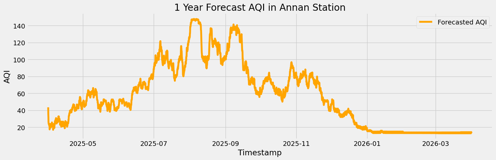

```python
#Make sure the predictions are in Series form with time index from updated_future_df
pred_series = pd.Series(predictions, index=updated_future_df.index[:len(predictions)])

# Plot
plt.figure(figsize=(15, 5))
plt.plot(pred_series.index, pred_series, label='Forecasted AQI', color='orange')
plt.title('1 Year Forecast AQI in Annan Station')
plt.xlabel('Timestamp')
plt.ylabel('AQI')
plt.grid(True)
plt.legend()
plt.tight_layout()
plt.show()
```

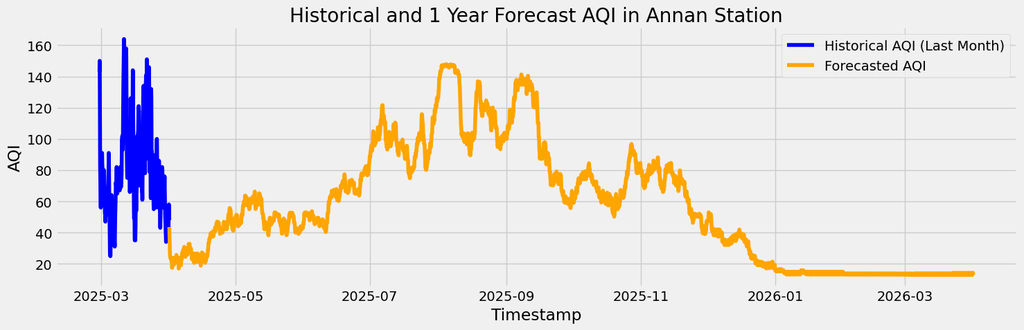

```python
plt.figure(figsize=(15, 5))
plt.plot(df_copy.index[-30*24:], df_copy['aqi'][-30*24:], label='Historical AQI (Last Month)', color='blue')
plt.plot(pred_series.index, pred_series, label='Forecasted AQI', color='orange')
plt.title('Historical and 1 Year Forecast AQI in Annan Station')
plt.xlabel('Timestamp')
plt.ylabel('AQI')
plt.grid(True)
plt.legend()
plt.tight_layout()
plt.show()
```

### (3) Anomaly Detection

For methods used in this project, we used Google Colab to construct the model

```
Training files: 35, Testing files: 36
Processing file 1/35: Annan_45_modified_6H.csv
```

```
Processed Annan_45_modified_6H.csv in 0.39 seconds
Processing file 2/35: Banqiao_6_modified_6H.csv
```

```
Processed Banqiao_6_modified_6H.csv in 0.32 seconds
Processing file 3/35: Cailiao_8_modified_6H.csv
```

```
Processed Cailiao_8_modified_6H.csv in 0.34 seconds
Processing file 4/35: Changhua_33_modified_6H.csv
```

```
Processed Changhua_33_modified_6H.csv in 0.33 seconds
Processing file 5/35: Chaozhou_60_modified_6H.csv
```

```
Processed Chaozhou_60_modified_6H.csv in 0.31 seconds
Processing file 6/35: Chiayi_42_modified_6H.csv
```

```
Processed Chiayi_42_modified_6H.csv in 0.33 seconds
Processing file 7/35: Dali_30_modified_6H.csv
```

```
Processed Dali_30_modified_6H.csv in 0.36 seconds
Processing file 8/35: Daliao_51_modified_6H.csv
```

```
Processed Daliao_51_modified_6H.csv in 0.31 seconds
Processing file 9/35: Dayuan_18_modified_6H.csv
```

```
Processed Dayuan_18_modified_6H.csv in 0.39 seconds
Processing file 10/35: Dongshan_66_modified_6H.csv
```

```
Processed Dongshan_66_modified_6H.csv in 0.29 seconds
Processing file 11/35: Douliu_37_modified_6H.csv
```

```
Processed Douliu_37_modified_6H.csv in 0.31 seconds
Processing file 12/35: Erlin_35_modified_6H.csv
```

```
Processed Erlin_35_modified_6H.csv in 0.48 seconds
Processing file 13/35: Fengyuan_28_modified_6H.csv
```

```
Processed Fengyuan_28_modified_6H.csv in 0.49 seconds
Processing file 14/35: Fuxing_71_modified_6H.csv
```

```
Processed Fuxing_71_modified_6H.csv in 0.33 seconds
Processing file 15/35: Guanyin_19_modified_6H.csv
```

```
Processed Guanyin_19_modified_6H.csv in 0.51 seconds
Processing file 16/35: Guting_14_modified_6H.csv
```

```
Processed Guting_14_modified_6H.csv in 0.35 seconds
Processing file 17/35: Hengchun_61_modified_6H.csv
```

```
Processed Hengchun_61_modified_6H.csv in 0.50 seconds
Processing file 18/35: Hsinchu_24_modified_6H.csv
```

```
Processed Hsinchu_24_modified_6H.csv in 0.39 seconds
Processing file 19/35: Hualien_63_modified_6H.csv
```

```
Processed Hualien_63_modified_6H.csv in 0.48 seconds
Processing file 20/35: Hukou_22_modified_6H.csv
```

```
Processed Hukou_22_modified_6H.csv in 0.42 seconds
Processing file 21/35: Keelung_1_modified_6H.csv
```

```
Processed Keelung_1_modified_6H.csv in 0.34 seconds
Processing file 22/35: Linkou_9_modified_6H.csv
```

```
Processed Linkou_9_modified_6H.csv in 0.46 seconds
Processing file 23/35: Linyuan_52_modified_6H.csv
```

```
Processed Linyuan_52_modified_6H.csv in 0.40 seconds
Processing file 24/35: Longtan_21_modified_6H.csv
```

```
Processed Longtan_21_modified_6H.csv in 0.35 seconds
Processing file 25/35: Lunbei_38_modified_6H.csv
```

```
Processed Lunbei_38_modified_6H.csv in 0.36 seconds
Processing file 26/35: Magong_78_modified_6H.csv
```

```
Processed Magong_78_modified_6H.csv in 0.28 seconds
Processing file 27/35: Mailiao_83_modified_6H.csv
```

```
Processed Mailiao_83_modified_6H.csv in 0.42 seconds
Processing file 28/35: Matsu_75_modified_6H.csv
```

```
Processed Matsu_75_modified_6H.csv in 0.35 seconds
Processing file 29/35: Meinong_47_modified_6H.csv
```

```
Processed Meinong_47_modified_6H.csv in 0.39 seconds
Processing file 30/35: Miaoli_26_modified_6H.csv
```

```
Processed Miaoli_26_modified_6H.csv in 0.33 seconds
Processing file 31/35: Nantou_36_modified_6H.csv
```

```
Processed Nantou_36_modified_6H.csv in 0.76 seconds
Processing file 32/35: Nanzi_53_modified_6H.csv
```

```
Processed Nanzi_53_modified_6H.csv in 0.46 seconds
Processing file 33/35: Pingtung_59_modified_6H.csv
```

```
Processed Pingtung_59_modified_6H.csv in 0.60 seconds
Processing file 34/35: Pingzhen_20_modified_6H.csv
```

```
Processed Pingzhen_20_modified_6H.csv in 0.31 seconds
Processing file 35/35: Puli_72_modified_6H.csv
```

```
Processed Puli_72_modified_6H.csv in 0.29 seconds
Processing file 1/36: Puzi_40_modified_6H.csv
```

```
Processed Puzi_40_modified_6H.csv in 0.33 seconds
Processing file 2/36: Qianjin_56_modified_6H.csv
```

```
Processed Qianjin_56_modified_6H.csv in 0.42 seconds
Processing file 3/36: Qianzhen_57_modified_6H.csv
```

```
Processed Qianzhen_57_modified_6H.csv in 0.33 seconds
Processing file 4/36: Qiaotou_48_modified_6H.csv
```

```
Processed Qiaotou_48_modified_6H.csv in 0.31 seconds
Processing file 5/36: Renwu_49_modified_6H.csv
```

```
Processed Renwu_49_modified_6H.csv in 0.36 seconds
Processing file 6/36: Sanyi_27_modified_6H.csv
```

```
Processed Sanyi_27_modified_6H.csv in 0.37 seconds
Processing file 7/36: Shalu_29_modified_6H.csv
```

```
Processed Shalu_29_modified_6H.csv in 0.45 seconds
Processing file 8/36: Shanhua_44_modified_6H.csv
```

```
Processed Shanhua_44_modified_6H.csv in 0.34 seconds
Processing file 9/36: Shilin_11_modified_6H.csv
```

```
Processed Shilin_11_modified_6H.csv in 0.50 seconds
Processing file 10/36: Songshan_15_modified_6H.csv
```

```
Processed Songshan_15_modified_6H.csv in 0.35 seconds
Processing file 11/36: Tainan_46_modified_6H.csv
```

```
Processed Tainan_46_modified_6H.csv in 0.33 seconds
Processing file 12/36: Taitung_62_modified_6H.csv
```

```
Processed Taitung_62_modified_6H.csv in 0.35 seconds
Processing file 13/36: Taixi_41_modified_6H.csv
```

```
Processed Taixi_41_modified_6H.csv in 0.38 seconds
Processing file 14/36: Tamsui_10_modified_6H.csv
```

```
Processed Tamsui_10_modified_6H.csv in 0.44 seconds
Processing file 15/36: Taoyuan_17_modified_6H.csv
```

```
Processed Taoyuan_17_modified_6H.csv in 0.30 seconds
Processing file 16/36: Toufen_25_modified_6H.csv
```

```
Processed Toufen_25_modified_6H.csv in 0.37 seconds
Processing file 17/36: Tucheng_5_modified_6H.csv
```

```
Processed Tucheng_5_modified_6H.csv in 0.45 seconds
Processing file 18/36: Wanhua_13_modified_6H.csv
```

```
Processed Wanhua_13_modified_6H.csv in 0.26 seconds
Processing file 19/36: Wanli_3_modified_6H.csv
```

```
Processed Wanli_3_modified_6H.csv in 0.33 seconds
Processing file 20/36: Xianxi_34_modified_6H.csv
```

```
Processed Xianxi_34_modified_6H.csv in 0.42 seconds
Processing file 21/36: Xiaogang_58_modified_6H.csv
```

```
Processed Xiaogang_58_modified_6H.csv in 0.44 seconds
Processing file 22/36: Xindian_4_modified_6H.csv
```

```
Processed Xindian_4_modified_6H.csv in 0.46 seconds
Processing file 23/36: Xingang_39_modified_6H.csv
```

```
Processed Xingang_39_modified_6H.csv in 0.33 seconds
Processing file 24/36: Xinying_43_modified_6H.csv
```

```
Processed Xinying_43_modified_6H.csv in 0.33 seconds
Processing file 25/36: Xinzhuang_7_modified_6H.csv
```

```
Processed Xinzhuang_7_modified_6H.csv in 0.46 seconds
Processing file 26/36: Xitun_32_modified_6H.csv
```

```
Processed Xitun_32_modified_6H.csv in 0.32 seconds
Processing file 27/36: Xizhi_2_modified_6H.csv
```

```
Processed Xizhi_2_modified_6H.csv in 0.37 seconds
Processing file 28/36: Yangming_64_modified_6H.csv
```

```
Processed Yangming_64_modified_6H.csv in 0.30 seconds
Processing file 29/36: Yilan_65_modified_6H.csv
```

```
Processed Yilan_65_modified_6H.csv in 0.31 seconds
Processing file 30/36: Yonghe_70_modified_6H.csv
```

```
Processed Yonghe_70_modified_6H.csv in 0.85 seconds
Processing file 31/36: Zhongli_68_modified_6H.csv
```

```
Processed Zhongli_68_modified_6H.csv in 0.27 seconds
Processing file 32/36: Zhongming_31_modified_6H.csv
```

```
Processed Zhongming_31_modified_6H.csv in 0.31 seconds
Processing file 33/36: Zhongshan_12_modified_6H.csv
```

```
Processed Zhongshan_12_modified_6H.csv in 0.29 seconds
Processing file 34/36: Zhudong_23_modified_6H.csv
```

```
Processed Zhudong_23_modified_6H.csv in 0.42 seconds
Processing file 35/36: Zhushan_69_modified_6H.csv
```

```
Processed Zhushan_69_modified_6H.csv in 0.29 seconds
Processing file 36/36: Zuoying_54_modified_6H.csv
```

```
Processed Zuoying_54_modified_6H.csv in 0.31 seconds
Train+Val shape: (426790, 25), Test shape: (438984, 25)
Data loading time: 27.33 seconds
Train shape: (341432, 25), Val shape: (85358, 25)
X_train shape: (341432, 20), X_test shape: (438984, 20)
NaNs in X_train: 0
SMOTE shape: (417124, 20), SMOTE time: 28.19 seconds
GridSearchCV time: 14574.33 seconds
Best parameters: {'max_depth': 10, 'min_samples_leaf': 1, 'min_samples_split': 5, 'n_estimators': 200}
Test set evaluation:
               precision    recall  f1-score   support

           0     0.9639    0.8476    0.9020    356968
           1     0.5651    0.8620    0.6826     82016

    accuracy                         0.8503    438984
   macro avg     0.7645    0.8548    0.7923    438984
weighted avg     0.8894    0.8503    0.8610    438984
```

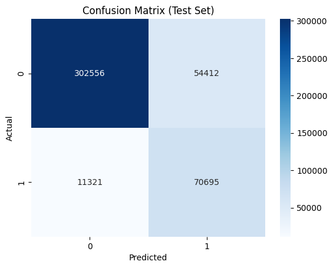

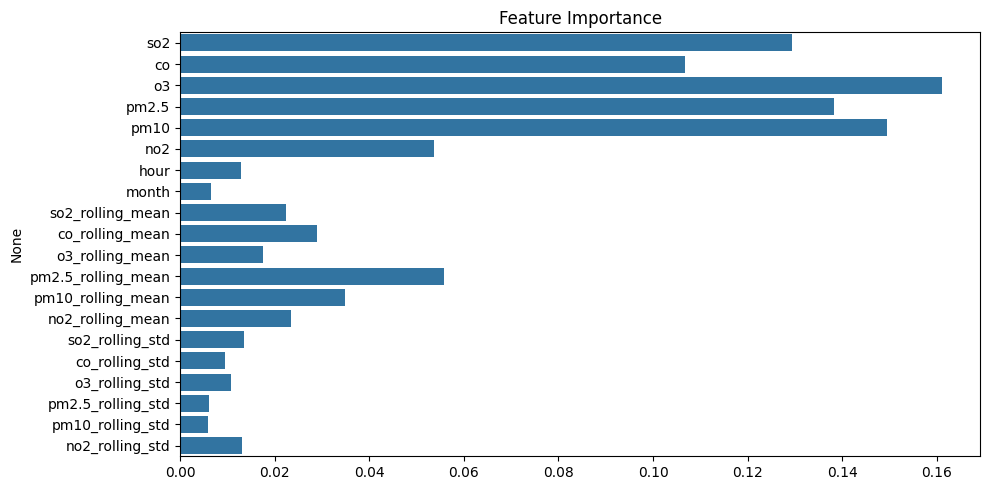

```
Model saved to: /content/drive/MyDrive/best_rf_model_35stations.joblib
```

```python
import os
import pandas as pd
import numpy as np
from sklearn.ensemble import RandomForestClassifier
from sklearn.model_selection import GridSearchCV, TimeSeriesSplit
from sklearn.metrics import classification_report, confusion_matrix
from imblearn.over_sampling import SMOTE
import matplotlib.pyplot as plt
import seaborn as sns
import joblib
import time

# Folder and parameters
data_folder = "/content/drive/MyDrive/Modified_Data_6H_CSV"
pollutants = ['so2', 'co', 'o3', 'pm2.5', 'pm10', 'no2']
thresholds = {p: None for p in pollutants}

# Load first 35 files as train/validation, last 36 as test
files = sorted([f for f in os.listdir(data_folder) if f.endswith('.csv')])
train_files = files[:35]
test_files = files[35:]
print(f"Training files: {len(train_files)}, Testing files: {len(test_files)}")

# Data processing function
def load_and_process(files):
    data = []
    for i, file in enumerate(files):
        print(f"Processing file {i+1}/{len(files)}: {file}")
        start_time = time.time()
        df = pd.read_csv(os.path.join(data_folder, file), parse_dates=['datacreationdate'])
        df.rename(columns={'datacreationdate': 'time'}, inplace=True)
        df['station'] = file.replace('_6H.csv', '')
        df = df.sort_values(by='time')
        df[pollutants] = df[pollutants].clip(lower=0).fillna(method='ffill')
        df['hour'] = df['time'].dt.hour
        df['month'] = df['time'].dt.month

        for p in pollutants:
            thresholds[p] = df[p].quantile(0.95)
        df['single_anomaly'] = df[pollutants].gt(pd.Series(thresholds)).any(axis=1).astype(int)

        for p in pollutants:
            df[f'{p}_rolling_mean'] = df[p].rolling(window=4).mean()
            df[f'{p}_rolling_std'] = df[p].rolling(window=4).std()

        data.append(df)
        print(f"Processed {file} in {time.time() - start_time:.2f} seconds")
    return pd.concat(data)

# Load data
start_time = time.time()
train_val_df = load_and_process(train_files)
test_df = load_and_process(test_files)
print(f"Train+Val shape: {train_val_df.shape}, Test shape: {test_df.shape}")
print(f"Data loading time: {time.time() - start_time:.2f} seconds")

# Split train and validation data
split_idx = int(len(train_val_df) * 0.8)
train_df = train_val_df.iloc[:split_idx]
val_df = train_val_df.iloc[split_idx:]
print(f"Train shape: {train_df.shape}, Val shape: {val_df.shape}")

# Features and labels
features = pollutants + ['hour', 'month'] + \
           [f'{p}_rolling_mean' for p in pollutants] + \
           [f'{p}_rolling_std' for p in pollutants]
label = 'single_anomaly'

X_train, y_train = train_df[features].fillna(0), train_df[label]
X_val, y_val = val_df[features].fillna(0), val_df[label]
X_test, y_test = test_df[features].fillna(0), test_df[label]
print(f"X_train shape: {X_train.shape}, X_test shape: {X_test.shape}")
print("NaNs in X_train:", X_train.isna().sum().sum())

# Handle imbalance
smote = SMOTE(random_state=42, sampling_strategy=0.5)
start_time = time.time()
X_train_resampled, y_train_resampled = smote.fit_resample(X_train, y_train)
print(f"SMOTE shape: {X_train_resampled.shape}, SMOTE time: {time.time() - start_time:.2f} seconds")

# Train Random Forest + GridSearchCV
param_grid = {
    'n_estimators': [100, 200],
    'max_depth': [5, 10, 20],
    'min_samples_split': [2, 5],
    'min_samples_leaf': [1, 2]
}
tscv = TimeSeriesSplit(n_splits=5)
clf = GridSearchCV(RandomForestClassifier(random_state=42, class_weight='balanced'),
                   param_grid, cv=tscv, scoring='f1')
start_time = time.time()
clf.fit(X_train_resampled, y_train_resampled)
print(f"GridSearchCV time: {time.time() - start_time:.2f} seconds")

# Prediction and evaluation
best_model = clf.best_estimator_
y_pred = best_model.predict(X_test)

print( "Best parameters:", clf.best_params_)
print("Test set evaluation:\n", classification_report(y_test, y_pred, digits=4))

# Confusion matrix
cm = confusion_matrix(y_test, y_pred)
sns.heatmap(cm, annot=True, fmt='d', cmap='Blues')
plt.title("Confusion Matrix (Test Set)")
plt.xlabel("Predicted")
plt.ylabel("Actual")
plt.show()

# Feature importance
importances = pd.Series(best_model.feature_importances_, index=features)
plt.figure(figsize=(10, 5))
sns.barplot(x=importances.values, y=importances.index)
plt.title("Feature Importance")
plt.tight_layout()
plt.show()

# Save model
model_path = '/content/drive/MyDrive/best_rf_model_35stations.joblib'
joblib.dump(best_model, model_path)
print(f"Model saved to: {model_path}")
```

# **References**

1. Kumar Dongre, P., Patel, V., Bhoi, U., & Maltare, N. N. (2025). An outlier detection framework for Air Quality Index prediction using linear and ensemble models. *Decision Analytics Journal*, 100546–100546. https://doi.org/10.1016/j.dajour.2025.100546
2. Mirabelli, M. C., Ebelt, S., & Damon, S. A. (2020). Air Quality Index and air quality awareness among adults in the United States. *Environmental Research, 183*, 109185. https://doi.org/10.1016/j.envres.2020.109185
3. Stanaway, J. D., Afshin, A., Gakidou, E., Lim, S. S., et al. (2018). Global, regional, and national comparative risk assessment of 84 behavioural, environmental and occupational, and metabolic risks or clusters of risks for 195 countries and territories, 1990–2017: a systematic analysis for the Global Burden of Disease Study 2017. *The Lancet, 392*(10159), 1923–1994. https://doi.org/10.1016/s0140-6736(18)32225-6